# Day 2 - Practical 2 - more advanced methods for metabolomics data analysis

##### **TASK 4**

Plot the URF score plot. Color the points by `Diagnosis`.

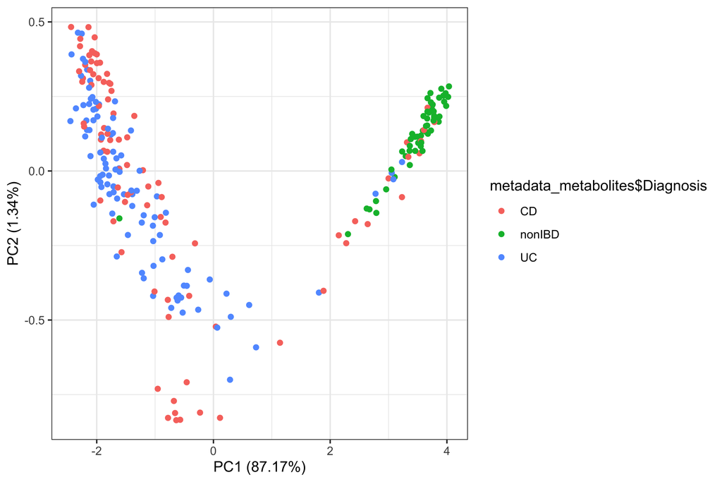

```r
ggplot(as.data.frame(URF$pc$x),
       aes(x = PC1,
           y = PC2,
           color = metadata_metabolites$Diagnosis)) +
  geom_point() +
  labs(x = paste0("PC1 (",round(URF$pr[1,2],2),"%)"),
       y = paste0("PC2 (",round(URF$pr[2,2],2),"%)")) +
  theme_bw()
```

# 5 ASCA

There are many versions of ASCA, depending on the application and **data design**. Today, we will only familiarize with one version: ASCA+ from the R package `limpca` (Thiel et al. 2023).

More information about the package, as well as tutorials and examples with datasets can be found [here](https://bioconductor.org/packages/release/bioc/html/limpca.html).

## 5.1 ASCA - case study

We are going to inspect the effect of the disease (nonIBD, UC, CD) and the duration of the disease on the metabolites’ profiles.

In our data, we have multiple samples per participant. This comes from sampling of patients at different times. However, we are not interested in in as it doesn’t follow any design.

Therefore, we have provided a new file `metadata_metabolites_asca.csv` with the metadata of only selected samples from the same time points, which contains an additional variable, `Age_at_diagnosis`, that we are interested in here.

##### **TASK 1**

Read `metadata_metabolites_asca.csv`. How many samples do we have now?

```r
metadata_metabolites_asca <- read.csv(file = here("data:papa2012/asca/metadata_metabolites_asca.csv"), row.names = 1)
nrow(metadata_metabolites_asca)
```

```
[1] 66
```

##### **TASK 2**

We also need to select those samples from the metabolites data table (PQN normalized).

```r
metabolites_asca <- metabolites_pqn[which(rownames(metabolites_pqn) %in% metadata_metabolites_asca$SampleID), ]
```

##### **TASK 3**

In the metadata, we don’t have information on the duration of the disease. However, we know participants age and the age at diagnosis. Calculate the duration of the disease and assign it to a new vector `duration_of_disease`. Then, add the vector to `metadata_metabolites_asca`.

```r
# write your code below
```

**SOLUTION:**

```r
duration_of_disease <- metadata_metabolites_asca$Age - metadata_metabolites_asca$Age_at_diagnosis

metadata_metabolites_asca$duration_of_disease <- duration_of_disease
```

## 5.2 Create an ASCA object

In order to use ASCA from the `limpca` package, the data need to be formatted as a list with the following elements:

- outcomes (multivariate matrix),
- design (data.frame) and
- formula (character string).

First, create an empty list:

```r
ASCA_model <- list()
```

##### **Design**

```r
ASCA_model$design <- data.frame(metadata_metabolites)
```

## References

Thiel, Michel, Nadia Benaiche, Manon Martin, Sébastien Franceschini, Robin Van Oirbeek, and Bernadette Govaerts. 2023. “Limpca: An R Package for the Linear Modeling of High-Dimensional Designed Data Based on ASCA/APCA Family of Methods.” *Journal of Chemometrics* 37 (7). https://doi.org/10.1002/cem.3482.